# 04 Validate and Summarize

## Validation rules

**Data Type**

1. Each column has its expected R type: factor for categories (`school`, `conference`, `year`, `position`, `hometown_state`, `hometown_country`, `match_method`, `hometown_match_level`, `hometown_place_type`, `hometown_median_income_censored`); character for text and IDs (`name`, `player_id`, `hometown_city`, `previous_school_1`–`N` (as many as the data contains), `hometown_geoid`, `hometown_county_geoid`, `hometown_county_name`); whole numbers for counts, yards and populations; numeric for measurements, rates and percentages.

**Presence**

2. The required columns `school`, `conference`, `name` and `position` contain no missing values. All other columns may be missing: stats are NA for players with no record in that category, and Census columns are NA for hometowns that did not match a Census geography.

**Range**

3. `height_in` is between 60 and 95 inches.
4. `weight_lbs` is between 100 and 5000 pounds.
5. `season` is 2026.
6. All percentage columns (race/ethnicity shares, `hometown_pct_male`, poverty rate, bachelor’s-or-higher share, `completion_percent`, `field_goal_percent`) are between 0 and 100.
7. `hometown_median_income` and `hometown_county_median_income` are between $2,500 and $250,000, the ACS reporting limits.
8. `hometown_median_age` is between 10 and 100 years.
9. Populations, land areas and population densities are not negative and are below realistic maximums: place population at most 10 million, county population at most 11 million, land area at most 150,000 square miles (about the size of the largest US county-equivalent, since county-level matches report the whole county’s area), density at most 100,000 people per square mile.
10. `hometown_latitude` is between 17 and 72 and `hometown_longitude` is between −180 and −64, which covers the US and Puerto Rico.
11. Stat counts are not negative and stay below realistic season maximums. Yardage may be negative, down to −500 yards, because lost yardage is real.
12. Longest plays are at most 100 yards, and longest field goals are at most 75 yards.

**Code**

13. `conference` is one of the 11 FBS conferences.
14. `year` is a value from 1 to 8.
15. Every position listed in `position` is a recognized spelled-out position name.
16. For US players, `hometown_state` is a valid USPS code (50 states, DC, PR, AS, GU, MP, VI).
17. `hometown_country` is a country name recognized under ISO 3166 (England, Scotland, Wales and Northern Ireland are accepted as UK constituent countries).
18. `hometown_geoid` has the length its `hometown_match_level` requires (7 digits for a place, 10 for a county subdivision, 5 for a county), its first two digits match the hometown state’s FIPS code, and `hometown_match_level` is filled in exactly when `hometown_geoid` is.
19. `hometown_county_geoid` is a 5-digit county FIPS code in the same state as the hometown geography.
20. `player_id` contains digits only.
21. `match_method` is “Exact name”, “First initial + last name” or “Similar name”.
22. `hometown_place_type` is a valid Census place or county subdivision type (city, town, village, borough, CDP, township, charter township, etc.). It is empty for county-level matches.
23. `hometown_median_income_censored` is “Bottom-coded (under $2,500)” or “Top-coded (over $250,000)”.

**Foreign key**

24. Every `player_id` exists in `player_stats_clean`.
25. Every `hometown_geoid` exists in `census_geography_2024_clean` at the geography level named by `hometown_match_level`.
26. Every `hometown_county_geoid` exists as a county in `census_geography_2024_clean`.

**Consistency**

27. Passing completions do not exceed passing attempts.
28. Field goals made do not exceed field goals attempted.
29. Extra points made do not exceed extra points attempted.
30. Fumbles lost do not exceed fumbles.
31. Solo tackles do not exceed total tackles.
32. Rushing touchdowns do not exceed rushing carries. Touchdowns on laterals or fumble recoveries may break this rule.
33. Receiving touchdowns do not exceed receptions.
34. `completion_percent` equals completions ÷ attempts × 100, within 1 point.
35. `kicking_points` equals 3 × field goals made + extra points made.
36. `rushing_yards_per_carry` equals rushing yards ÷ carries, within 0.15.
37. `match_method` is filled in exactly when `player_id` is.
38. Each school belongs to exactly one conference.
39. The five race/ethnicity shares sum to 100%, within 0.01.
40. `hometown_median_income_censored` is set exactly when income sits at the $2,500 or $250,000 limit.

**Uniqueness**

41. Each `player_id` appears at most once.
42. No player appears twice, judged by school + name + position + hometown city.
43. All 139 FBS schools are present.
44. All 11 FBS conferences are present.
45. Rosters contain only players: no coaches or support staff, no Team IMPACT honorary members (children placed on teams through the charity), no memorial entries, and no honorary captains. Checked by searching `name` and `position` for staff titles (coach, coordinator, director, analyst, trainer, manager), “IMPACT”, “In Memory” and “Captain”.

**Other Business rules for the project**

46. API keys are stored in a `.Renviron` file in the project root.
47. `.Renviron` defines both `CFBD_API_KEY` and `CENSUS_API_KEY`.
48. No API key is hard-coded in any `.Rmd` file.
49. `.Renviron` is listed in `.gitignore`, so the keys are never committed.
50. Tidy: each observation (one player) forms one row, with no duplicate rows.
51. Tidy: each variable forms one column. Exceptions are flagged: multiple positions stored in one cell, and the `previous_school_1`–`N` repeating group.
52. Tidy: each cell holds a single value.
53. Technically correct: every column name is snake_case and describes its contents, including units where relevant (for example `height_in`, `weight_lbs`).
54. Technically correct: every column’s data type matches its contents (rule 1).
55. Consistent with the research question: the dataset includes every variable the question needs, namely players, hometown population, median income, population density, education, and poverty rate.
56. Per-capita rates are only computed for hometowns with a population above 0.
57. Per-capita analysis includes communities that produced zero players, so rates are not biased upward.
58. Failed joins are identified: US hometowns (city + state) that did not match a Census place, county subdivision or county.
59. Failed joins are identified: CFBD players who did not match a roster player.

**Probabilistic**

60. A player’s weight is flagged if it is more than 3.5 robust standard deviations (median absolute deviation) from the median for his position.
61. A player’s height is flagged if it is more than 3.5 robust standard deviations (median absolute deviation) from the median for his position.
62. A school’s roster size is flagged if it falls outside the IQR fences (Q1 − 1.5 × IQR, Q3 + 1.5 × IQR).
63. A school is flagged if its missing rate for `year`, `height_in`, `weight_lbs` or `hometown_city` is far above the overall rate (binomial z > 3).
64. Players whose hometowns matched a Census geography and players whose hometowns did not should have similar height and weight distributions. A significant difference would mean the failed joins bias the sample.

## Validation table

### Loading the data

```r
processed_dir = "../data/processed"

# Merged dataset: IDs and codes as text, then restore the factor types lost in the CSV.
# guess_max = Inf guesses each type from every row, so sparse columns such as
# previous_school_4 are read as text rather than mistaken for empty logical columns.
fbs_players = readr::read_csv(
  file.path(processed_dir, "fbs_players_merged.csv"),
  col_types = readr::cols(player_id = "c", hometown_geoid = "c", hometown_county_geoid = "c",
                          year = "c", hometown_state = "c", .default = readr::col_guess()),
  guess_max = Inf, show_col_types = FALSE
) |>
  dplyr::mutate(
    dplyr::across(c(school, conference, position, hometown_state, hometown_country, match_method,
                    hometown_match_level, hometown_place_type, hometown_median_income_censored), factor),
    year = factor(year, levels = as.character(1:8))
  )

# Source tables for the foreign-key and failed-join rules
player_stats_clean = readr::read_csv(
  file.path(processed_dir, "player_stats_clean.csv"),
  col_types = readr::cols(player_id = "c", .default = readr::col_guess()), show_col_types = FALSE
)
census_clean = readr::read_csv(
  file.path(processed_dir, "census_geography_2024_clean.csv"),
  col_types = readr::cols(geography_level = "c", geoid = "c", name = "c", place_type = "c",
                          is_statistical_area = "l", state_abbr = "c", median_income_censored = "c",
                          county_geoid = "c", county_name = "c", county_match_status = "c",
                          county_count = "i", multiple_counties = "l", .default = "d")
)

message(nrow(fbs_players), " rows x ", ncol(fbs_players), " columns")
```

### Rules, reference lists and column constraints

```r
# ---- Rule catalog: every rule above, with the kind of problem it catches ----
rule_catalog = tibble::tribble(
  ~rule, ~category,       ~check_type,                    ~description,
  1,  "Data type",        "Wrong data type",              "Each column has its expected R type",
  2,  "Presence",         "Missing required value",       "school, conference, name and position are never missing",
  3,  "Range",            "Impossible value",             "height_in is between 60 and 95",
  4,  "Range",            "Impossible value",             "weight_lbs is between 100 and 5000",
  5,  "Range",            "Impossible value",             "season is 2026",
  6,  "Range",            "Impossible value",             "Percentage columns are between 0 and 100",
  7,  "Range",            "Impossible value",             "Median incomes are between $2,500 and $250,000",
  8,  "Range",            "Impossible value",             "hometown_median_age is between 10 and 100",
  9,  "Range",            "Impossible value",             "Populations, land areas and densities are non-negative and below realistic maximums",
  10, "Range",            "Impossible value",             "Latitude 17 to 72 and longitude -180 to -64",
  11, "Range",            "Impossible value",             "Stat counts non-negative and below season maximums; yardage at least -500",
  12, "Range",            "Impossible value",             "Longest plays at most 100 yards; longest field goal at most 75",
  13, "Code",             "Invalid category",             "conference is one of the 11 FBS conferences",
  14, "Code",             "Invalid category",             "year is 1-8",
  15, "Code",             "Invalid category",             "Every listed position is a recognized spelled-out position",
  16, "Code",             "Invalid category",             "US hometown_state is a valid USPS code",
  17, "Code",             "Invalid category",             "hometown_country is an ISO 3166 country (or UK constituent country)",
  18, "Code",             "Invalid category",             "hometown_geoid length matches its match level (7/10/5) and starts with the state FIPS code",
  19, "Code",             "Invalid category",             "hometown_county_geoid is 5 digits and in the same state as the hometown",
  20, "Code",             "Invalid category",             "player_id contains digits only",
  21, "Code",             "Invalid category",             "match_method is a defined method",
  22, "Code",             "Invalid category",             "hometown_place_type is a valid Census place or county subdivision type",
  23, "Code",             "Invalid category",             "hometown_median_income_censored is a defined level",
  24, "Foreign key",      "Failed join",                  "player_id exists in player_stats_clean",
  25, "Foreign key",      "Failed join",                  "hometown_geoid exists at its match level in the Census data",
  26, "Foreign key",      "Failed join",                  "hometown_county_geoid exists as a Census county",
  27, "Consistency",      "Inconsistent values",          "Completions <= attempts",
  28, "Consistency",      "Inconsistent values",          "Field goals made <= attempted",
  29, "Consistency",      "Inconsistent values",          "Extra points made <= attempted",
  30, "Consistency",      "Inconsistent values",          "Fumbles lost <= fumbles",
  31, "Consistency",      "Inconsistent values",          "Solo tackles <= total tackles",
  32, "Consistency",      "Inconsistent values",          "Rushing touchdowns <= carries (laterals/fumble recoveries may break this)",
  33, "Consistency",      "Inconsistent values",          "Receiving touchdowns <= receptions",
  34, "Consistency",      "Inconsistent values",          "Completion % = completions / attempts x 100 (within 1 point)",
  35, "Consistency",      "Inconsistent values",          "Kicking points = 3 x field goals made + extra points made",
  36, "Consistency",      "Inconsistent values",          "Yards per carry = yards / carries (within 0.15)",
  37, "Consistency",      "Inconsistent values",          "match_method is filled exactly when player_id is",
  38, "Consistency",      "Inconsistent values",          "Each school belongs to exactly one conference",
  39, "Consistency",      "Inconsistent values",          "Race/ethnicity shares sum to 100% (within 0.01)",
  40, "Consistency",      "Inconsistent values",          "Censoring flag is set exactly when income is at $2,500 or $250,000",
  41, "Uniqueness",       "Duplicate entry",              "Each player_id appears at most once",
  42, "Uniqueness",       "Duplicate entry",              "No player appears twice (school + name + position + hometown city)",
  43, "Uniqueness",       "Missing group",                "All 139 FBS schools are present",
  44, "Uniqueness",       "Missing group",                "All 11 FBS conferences are present",
  45, "Uniqueness",       "Non-player entry",             "Only players: no coaches/staff, Team IMPACT members, memorial entries or honorary captains",
  46, "Business rule",    "Business rule",                "API keys are stored in .Renviron in the project root",
  47, "Business rule",    "Business rule",                ".Renviron defines CFBD_API_KEY and CENSUS_API_KEY",
  48, "Business rule",    "Business rule",                "No API key is hard-coded in any .Rmd file",
  49, "Business rule",    "Business rule",                ".Renviron is listed in .gitignore",
  50, "Business rule",    "Duplicate entry",              "Tidy: one row per player, no duplicate rows",
  51, "Business rule",    "Business rule",                "Tidy: each variable forms one column (exceptions flagged)",
  52, "Business rule",    "Multiple values in one cell",  "Tidy: each cell holds a single value",
  53, "Business rule",    "Business rule",                "Technically correct: snake_case, descriptive column names",
  54, "Business rule",    "Wrong data type",              "Technically correct: every column has its expected type (rule 1)",
  55, "Business rule",    "Business rule",                "Dataset holds every variable the research question needs",
  56, "Business rule",    "Zero population",              "Per-capita rates only for hometowns with population above 0",
  57, "Business rule",    "Business rule",                "Per-capita analysis includes communities with zero players",
  58, "Business rule",    "Failed join",                  "Failed join: US hometown did not match a Census geography",
  59, "Business rule",    "Failed join",                  "Failed join: CFBD player did not match a roster player",
  60, "Probabilistic",    "Statistical outlier",          "Weight more than 3.5 robust SDs from the position median",
  61, "Probabilistic",    "Statistical outlier",          "Height more than 3.5 robust SDs from the position median",
  62, "Probabilistic",    "Statistical outlier",          "School roster size outside the IQR fences",
  63, "Probabilistic",    "Statistical outlier",          "School missing rate far above the overall rate (binomial z > 3)",
  64, "Probabilistic",    "Statistical outlier",          "Census-matched and unmatched players have similar height/weight (KS p > 0.01)"
) |>
  dplyr::mutate(rule = as.integer(rule))
```

```r
# ---- Reference code lists ----
fbs_conferences = c("ACC", "American", "Big 12", "Big Ten", "Conference USA", "FBS Independent",
                    "MAC", "Mountain West", "Pac-12", "SEC", "Sun Belt")
valid_positions = c("Quarterback", "Running Back", "Fullback", "Slotback", "Athlete", "Wide Receiver",
                    "Slot Receiver", "Tight End", "Offensive Lineman", "Interior Offensive Lineman",
                    "Offensive Tackle", "Offensive Guard", "Center", "Defensive Lineman", "Defensive End",
                    "End", "Defensive Tackle", "Nose Tackle", "Edge Rusher", "Jack", "Bandit", "Linebacker",
                    "Outside Linebacker", "Inside Linebacker", "Money Backer", "Defensive Back", "Cornerback",
                    "Safety", "Nickelback", "Star", "Spur", "Viper", "Kicker", "Punter", "Long Snapper")
usps_codes         = c(state.abb, "DC", "PR", "AS", "GU", "MP", "VI")
census_place_types = c("city and borough", "unified government", "consolidated government",
                       "metropolitan government", "metro government", "metro township", "urban county",
                       "zona urbana", "comunidad", "municipality", "corporation",
                       "borough", "village", "town", "city", "CDP",
                       # county subdivision types (towns and townships)
                       "charter township", "township", "barrio-pueblo", "barrio", "plantation",
                       "precinct", "district", "grant", "gore", "location", "purchase")
match_methods      = c("Exact name", "First initial + last name", "Similar name")
match_levels       = c("Place", "County subdivision", "County")
geoid_digits       = c("Place" = 7L, "County subdivision" = 10L, "County" = 5L)
censored_levels    = c("Bottom-coded (under $2,500)", "Top-coded (over $250,000)")
state_fips         = dplyr::distinct(tidycensus::fips_codes, state, state_code)
uk_constituents    = c("England", "Scotland", "Wales", "Northern Ireland")

# ---- Column constraints: type, nullability, range, allowed values and foreign keys ----
id_spec = tibble::tribble(
  ~column,                               ~expected_type, ~nullable, ~min,  ~max,   ~range_rule, ~allowed_values,                            ~foreign_key,
  "school",                              "factor",       FALSE,     NA,    NA,     NA,          "139 FBS schools",                          NA,
  "conference",                          "factor",       FALSE,     NA,    NA,     NA,          "11 FBS conferences",                       NA,
  "name",                                "character",    FALSE,     NA,    NA,     NA,          NA,                                         NA,
  "year",                                "factor",       TRUE,      NA,    NA,     NA,          "1-8",                                      NA,
  "position",                            "factor",       FALSE,     NA,    NA,     NA,          "Spelled-out positions",                    NA,
  "player_id",                           "character",    TRUE,      NA,    NA,     NA,          "Digits only",                              "player_stats_clean.player_id",
  "match_method",                        "factor",       TRUE,      NA,    NA,     NA,          "Exact name; First initial + last name; Similar name", NA,
  "season",                              "whole number", TRUE,      2026,  2026,   5,           NA,                                         NA,
  "height_in",                           "numeric",      TRUE,      60,    95,     3,           NA,                                         NA,
  "weight_lbs",                          "whole number", TRUE,      100,   5000,   4,           NA,                                         NA,
  "hometown_city",                       "character",    TRUE,      NA,    NA,     NA,          NA,                                         NA,
  "hometown_state",                      "factor",       TRUE,      NA,    NA,     NA,          "USPS code (US) or province name",          NA,
  "hometown_country",                    "factor",       TRUE,      NA,    NA,     NA,          "ISO 3166 country name",                    NA,
  "hometown_geoid",                      "character",    TRUE,      NA,    NA,     NA,          "7-digit place, 10-digit county subdivision or 5-digit county FIPS", "census_geography_2024_clean.geoid (at hometown_match_level)",
  "hometown_match_level",                "factor",       TRUE,      NA,    NA,     NA,          "Place; County subdivision; County",        NA,
  "hometown_place_type",                 "factor",       TRUE,      NA,    NA,     NA,          "Census place or county subdivision types", NA,
  "hometown_population",                 "whole number", TRUE,      0,     1e7,    9,           NA,                                         NA,
  "hometown_median_age",                 "numeric",      TRUE,      10,    100,    8,           NA,                                         NA,
  "hometown_pct_male",                   "numeric",      TRUE,      0,     100,    6,           NA,                                         NA,
  "hometown_pct_white",                  "numeric",      TRUE,      0,     100,    6,           NA,                                         NA,
  "hometown_pct_black",                  "numeric",      TRUE,      0,     100,    6,           NA,                                         NA,
  "hometown_pct_asian",                  "numeric",      TRUE,      0,     100,    6,           NA,                                         NA,
  "hometown_pct_hispanic",               "numeric",      TRUE,      0,     100,    6,           NA,                                         NA,
  "hometown_pct_other_race",             "numeric",      TRUE,      0,     100,    6,           NA,                                         NA,
  "hometown_median_income",              "numeric",      TRUE,      2500,  250000, 7,           NA,                                         NA,
  "hometown_median_income_censored",     "factor",       TRUE,      NA,    NA,     NA,          "Bottom-coded; Top-coded",                  NA,
  "hometown_poverty_rate",               "numeric",      TRUE,      0,     100,    6,           NA,                                         NA,
  "hometown_bachelors_or_higher",        "numeric",      TRUE,      0,     100,    6,           NA,                                         NA,
  "hometown_longitude",                  "numeric",      TRUE,      -180,  -64,    10,          NA,                                         NA,
  "hometown_latitude",                   "numeric",      TRUE,      17,    72,     10,          NA,                                         NA,
  "hometown_land_area_sqmi",             "numeric",      TRUE,      0,     1.5e5,  9,           NA,                                         NA,
  "hometown_population_density",         "numeric",      TRUE,      0,     1e5,    9,           NA,                                         NA,
  "hometown_county_geoid",               "character",    TRUE,      NA,    NA,     NA,          "5-digit county FIPS",                      "census_geography_2024_clean.geoid (county)",
  "hometown_county_name",                "character",    TRUE,      NA,    NA,     NA,          NA,                                         NA,
  "hometown_county_population",          "whole number", TRUE,      0,     1.1e7,  9,           NA,                                         NA,
  "hometown_county_median_income",       "numeric",      TRUE,      2500,  250000, 7,           NA,                                         NA,
  "hometown_county_poverty_rate",        "numeric",      TRUE,      0,     100,    6,           NA,                                         NA,
  "hometown_county_bachelors_or_higher", "numeric",      TRUE,      0,     100,    6,           NA,                                         NA,
  "hometown_county_population_density",  "numeric",      TRUE,      0,     1e5,    9,           NA,                                         NA
)
```

```r
# Stat columns: type and limits follow from the unit in the column name
stat_spec = tibble::tibble(
  column = setdiff(names(player_stats_clean), c("season", "player_id", "school", "conference", "name", "position"))
) |>
  dplyr::mutate(
    expected_type  = dplyr::if_else(stringr::str_detect(column, "_per_|_percent$|^sacks$|^tackles_for_loss$"),
                                    "numeric", "whole number"),
    nullable       = TRUE,                                        # NA = no record in that category
    min = dplyr::case_when(
      stringr::str_detect(column, "_percent$")                   ~ 0,
      stringr::str_detect(column, "_per_|longest_yards$")        ~ -100,
      stringr::str_detect(column, "_yards$")                     ~ -500,
      TRUE                                                       ~ 0
    ),
    max = dplyr::case_when(
      stringr::str_detect(column, "_percent$|_per_")             ~ 100,
      column == "field_goal_longest_yards"                       ~ 75,
      stringr::str_detect(column, "longest_yards$")              ~ 100,
      column %in% c("passing_yards", "punting_yards")            ~ 6000,
      stringr::str_detect(column, "_yards$")                     ~ 3000,
      column %in% c("passing_attempts", "passing_completions")   ~ 700,
      column == "rushing_carries"                                ~ 450,
      TRUE                                                       ~ 200
    ),
    range_rule = dplyr::case_when(
      stringr::str_detect(column, "_percent$")                   ~ 6L,
      stringr::str_detect(column, "longest_yards$")              ~ 12L,
      TRUE                                                       ~ 11L
    )
  )

# Previous-school columns: one row for however many the merged data contains
previous_spec = tibble::tibble(column = grep("^previous_school_\\d+$", names(fbs_players), value = TRUE),
                               expected_type = "character", nullable = TRUE)

column_spec = dplyr::bind_rows(
  dplyr::mutate(id_spec, dplyr::across(c(min, max), as.numeric), range_rule = as.integer(range_rule)),
  previous_spec,
  stat_spec
)
stopifnot(setequal(column_spec$column, names(fbs_players)))          # every column specified exactly once
```

### Running the checks

```r
# ---- Row-level checks: TRUE = the row BREAKS the rule; NA comparisons count as passing ----
chk = function(rule, column, flags) {
  tibble::tibble(rule = as.integer(rule), column = column,
                 flags = list(tidyr::replace_na(as.logical(flags), FALSE)))
}
not_in = function(x, allowed) !is.na(x) & !(as.character(x) %in% allowed)

robust_z = function(x) {
  s = stats::mad(x, na.rm = TRUE)
  if (is.na(s) || s == 0) return(rep(0, length(x)))
  (x - stats::median(x, na.rm = TRUE)) / s
}

# Helper vectors
row_state_fips  = state_fips$state_code[match(as.character(fbs_players$hometown_state), state_fips$state)]
position_ok     = purrr::map_lgl(stringr::str_split(as.character(fbs_players$position), "/"),
                                 ~ all(is.na(.x)) || all(.x %in% valid_positions))
country_ok      = is.na(fbs_players$hometown_country) | fbs_players$hometown_country %in% uk_constituents |
                  !is.na(suppressWarnings(countrycode::countryname(as.character(fbs_players$hometown_country),
                                                                   destination = "iso3c", warn = FALSE)))
race_sum        = rowSums(fbs_players[c("hometown_pct_white", "hometown_pct_black", "hometown_pct_asian",
                                        "hometown_pct_hispanic", "hometown_pct_other_race")])
multi_conf      = fbs_players |> dplyr::distinct(school, conference) |> dplyr::count(school) |>
                  dplyr::filter(n > 1) |> dplyr::pull(school)
player_key      = paste(fbs_players$school, fbs_players$name, fbs_players$position, fbs_players$hometown_city, sep = "|")
staff_terms     = "(?i)\\b(coach|coordinator|director|analyst|trainer|manager)\\b"
census_keys     = paste(census_clean$geography_level, census_clean$geoid)
level_key       = c("Place" = "place", "County subdivision" = "county subdivision", "County" = "county")
hometown_key    = paste(level_key[as.character(fbs_players$hometown_match_level)], fbs_players$hometown_geoid)
county_geoids   = census_clean$geoid[census_clean$geography_level == "county"]
expected_digits = geoid_digits[as.character(fbs_players$hometown_match_level)]
z               = fbs_players |>
                  dplyr::group_by(position) |>
                  dplyr::mutate(z_weight = robust_z(weight_lbs), z_height = robust_z(height_in)) |>
                  dplyr::ungroup()

# Rules 3-12: ranges, generated from the column constraints
range_checks = column_spec |>
  dplyr::filter(!is.na(range_rule)) |>
  purrr::pmap(function(column, min, max, range_rule, ...) {
    x = fbs_players[[column]]
    chk(range_rule, column, x < min | x > max)
  }) |>
  dplyr::bind_rows()

# All other row-level rules
rule_checks = with(fbs_players, dplyr::bind_rows(
  # Presence
  purrr::map(c("school", "conference", "name", "position"), ~ chk(2, .x, is.na(fbs_players[[.x]]))),
  # Code
  chk(13, "conference",          !(as.character(conference) %in% fbs_conferences)),
  chk(14, "year",                not_in(year, as.character(1:8))),
  chk(15, "position",            !position_ok),
  chk(16, "hometown_state",      hometown_country %in% "United States" & not_in(hometown_state, usps_codes)),
  chk(17, "hometown_country",    !country_ok),
  chk(18, "hometown_geoid, hometown_match_level, hometown_state",
      is.na(hometown_geoid) != is.na(hometown_match_level) |
        (!is.na(hometown_geoid) & (!stringr::str_detect(hometown_geoid, "^\\d+$") | nchar(hometown_geoid) != expected_digits |
                                     is.na(row_state_fips) | substr(hometown_geoid, 1, 2) != row_state_fips))),
  chk(19, "hometown_county_geoid, hometown_geoid",
      !stringr::str_detect(hometown_county_geoid, "^\\d{5}$") | substr(hometown_county_geoid, 1, 2) != substr(hometown_geoid, 1, 2)),
  chk(20, "player_id",           !stringr::str_detect(player_id, "^\\d+$")),
  chk(21, "match_method",        not_in(match_method, match_methods)),
  chk(22, "hometown_place_type", not_in(hometown_place_type, census_place_types)),
  chk(23, "hometown_median_income_censored", not_in(hometown_median_income_censored, censored_levels)),
  # Foreign key
  chk(24, "player_id",             not_in(player_id, player_stats_clean$player_id)),
  chk(25, "hometown_geoid, hometown_match_level", !is.na(hometown_geoid) & !(hometown_key %in% census_keys)),
  chk(26, "hometown_county_geoid", not_in(hometown_county_geoid, county_geoids)),
  # Consistency
  chk(27, "passing_completions, passing_attempts",          passing_completions > passing_attempts),
  chk(28, "field_goals_made, field_goals_attempted",        field_goals_made > field_goals_attempted),
  chk(29, "extra_points_made, extra_points_attempted",      extra_points_made > extra_points_attempted),
  chk(30, "fumbles_lost, fumbles",                          fumbles_lost > fumbles),
  chk(31, "tackles_solo, tackles_total",                    tackles_solo > tackles_total),
  chk(32, "rushing_touchdowns, rushing_carries",            rushing_touchdowns > rushing_carries),
  chk(33, "receiving_touchdowns, receptions",               receiving_touchdowns > receptions),
  chk(34, "completion_percent, passing_completions, passing_attempts",
      passing_attempts > 0 & abs(passing_completions / passing_attempts * 100 - completion_percent) > 1),
  chk(35, "kicking_points, field_goals_made, extra_points_made",
      kicking_points != 3 * field_goals_made + extra_points_made),
  chk(36, "rushing_yards_per_carry, rushing_yards, rushing_carries",
      rushing_carries > 0 & abs(rushing_yards / rushing_carries - rushing_yards_per_carry) > 0.15),
  chk(37, "match_method, player_id",                        is.na(match_method) != is.na(player_id)),
  chk(38, "school, conference",                             school %in% multi_conf),
  chk(39, "hometown_pct_white, hometown_pct_black, hometown_pct_asian, hometown_pct_hispanic, hometown_pct_other_race",
      abs(race_sum - 100) > 0.01),
  chk(40, "hometown_median_income_censored, hometown_median_income",
      !is.na(hometown_median_income) & (hometown_median_income %in% c(2500, 250000)) != !is.na(hometown_median_income_censored)),
  # Uniqueness
  chk(41, "player_id",  !is.na(player_id) & (duplicated(player_id) | duplicated(player_id, fromLast = TRUE))),
  chk(42, "school, name, position, hometown_city", duplicated(player_key) | duplicated(player_key, fromLast = TRUE)),
  chk(45, "name, position",
      stringr::str_detect(name, staff_terms) | stringr::str_detect(name, "(?i)^in memory|impact") |
        stringr::str_detect(as.character(position), paste0(staff_terms, "|impact|^captain$"))),
  # Business rules
  chk(50, "school, name, position, hometown_city", duplicated(player_key)),
  chk(52, "position",            stringr::str_detect(as.character(position), "/")),
  chk(56, "hometown_population", !is.na(hometown_geoid) & hometown_population %in% 0),
  chk(58, "hometown_city, hometown_state, hometown_geoid",
      hometown_country %in% "United States" & !is.na(hometown_city) & !is.na(hometown_state) & is.na(hometown_geoid)),
  # Probabilistic
  chk(60, "weight_lbs", abs(z$z_weight) > 3.5),
  chk(61, "height_in",  abs(z$z_height) > 3.5)
))
```

```r
row_checks = dplyr::bind_rows(range_checks, rule_checks)

# ---- Table- and group-level checks ----
type_ok = function(x, expected) {
  switch(expected,
         "factor"       = is.factor(x),
         "character"    = is.character(x),
         "numeric"      = is.numeric(x),
         "whole number" = is.numeric(x) && all(x == round(x), na.rm = TRUE))
}
column_spec$type_ok = purrr::map2_lgl(column_spec$column, column_spec$expected_type, ~ type_ok(fbs_players[[.x]], .y))

# Rules 46-49: API keys (key names are checked; values are never printed)
renviron_path = here::here(".Renviron")
renviron      = if (file.exists(renviron_path)) readLines(renviron_path, warn = FALSE) else character()
rmd_files     = list.files(here::here(), pattern = "\\.Rmd$", recursive = TRUE, full.names = TRUE)
hardcoded     = purrr::keep(rmd_files, ~ any(stringr::str_detect(
  readLines(.x, warn = FALSE), "(?i)(api_?key|bearer|token)\\s*(=|<-)\\s*[\"'][A-Za-z0-9+/=_-]{20,}[\"']")))
gitignore     = here::here(".gitignore")
keys_ignored  = file.exists(gitignore) && any(stringr::str_detect(readLines(gitignore, warn = FALSE), "^/?\\.Renviron$"))

# Rule 55: variables the research question needs
needed = c(players = "name", population = "hometown_population", income = "hometown_median_income",
           density = "hometown_population_density", education = "hometown_bachelors_or_higher",
           poverty = "hometown_poverty_rate")
needed_missing = needed[!needed %in% names(fbs_players)]

# Rule 57: community table built from EVERY Census place, including places with zero players
community = census_clean |>
  dplyr::filter(geography_level == "place") |>
  dplyr::left_join(dplyr::count(fbs_players, hometown_geoid, name = "players"), by = c("geoid" = "hometown_geoid")) |>
  dplyr::mutate(players         = dplyr::coalesce(players, 0L),
                players_per_10k = dplyr::if_else(population > 0, players / population * 1e4, NA_real_))

# Rule 59: CFBD players that did not join a roster player
stats_unmatched = dplyr::filter(player_stats_clean, !player_id %in% fbs_players$player_id)

# Rule 62: roster sizes outside the IQR fences
roster_sizes    = dplyr::count(fbs_players, school, name = "players")
q               = stats::quantile(roster_sizes$players, c(0.25, 0.75))
fences          = c(q[[1]] - 1.5 * diff(q), q[[2]] + 1.5 * diff(q))
roster_outliers = dplyr::filter(roster_sizes, players < fences[1] | players > fences[2])

# Rule 63: school missingness spikes
missingness_spikes = purrr::map_dfr(c("year", "height_in", "weight_lbs", "hometown_city"), function(col) {
  p_all = mean(is.na(fbs_players[[col]]))
  fbs_players |>
    dplyr::group_by(school) |>
    dplyr::summarise(n = dplyr::n(), pct_missing = mean(is.na(.data[[col]])), .groups = "drop") |>
    dplyr::mutate(column = col, overall_pct = p_all,
                  z = (pct_missing - p_all) / sqrt(pmax(p_all * (1 - p_all), 1e-9) / n))
}) |>
  dplyr::filter(z > 3)

# Rule 64: KS test, Census-matched vs unmatched US players
us_rows = fbs_players$hometown_country %in% "United States"
ks_results = purrr::map_dfr(c("height_in", "weight_lbs"), function(col) {
  x = fbs_players[[col]]
  t = suppressWarnings(stats::ks.test(stats::na.omit(x[us_rows & !is.na(fbs_players$hometown_geoid)]),
                                      stats::na.omit(x[us_rows &  is.na(fbs_players$hometown_geoid)])))
  tibble::tibble(column = col, D = unname(t$statistic), p_value = t$p.value)
})

wrong_type_cols = paste(column_spec$column[!column_spec$type_ok], collapse = ", ")

table_checks = tibble::tribble(
  ~rule, ~passed,                                                         ~column,                                                   ~detail,
  1,  all(column_spec$type_ok),                                           wrong_type_cols,                                           paste(sum(!column_spec$type_ok), "column(s) with the wrong type"),
  43, dplyr::n_distinct(fbs_players$school) == 139,                       "school",                                                  paste(dplyr::n_distinct(fbs_players$school), "schools"),
  44, dplyr::n_distinct(fbs_players$conference) == 11,                    "conference",                                              paste(dplyr::n_distinct(fbs_players$conference), "conferences"),
  46, file.exists(renviron_path),                                         NA,                                                        "Looked for .Renviron in the project root",
  47, all(c("CFBD_API_KEY", "CENSUS_API_KEY") %in% trimws(sub("=.*$", "", renviron))), NA,                                       "Key names checked; values not printed",
  48, length(hardcoded) == 0,                                             NA,                                                        if (length(hardcoded)) paste("Hard-coded key in", paste(basename(hardcoded), collapse = ", ")) else paste(length(rmd_files), ".Rmd files scanned"),
  49, keys_ignored,                                                       NA,                                                        if (file.exists(gitignore)) ".Renviron not listed in .gitignore" else "No .gitignore found",
  51, FALSE,                                                              paste(previous_spec$column, collapse = ", "),             paste0("previous_school_1-", nrow(previous_spec), " is a repeating group (kept wide on purpose); multi-position cells flagged under rule 52"),
  53, all(stringr::str_detect(names(fbs_players), "^[a-z][a-z0-9_]*$")),  NA,                                                        paste(ncol(fbs_players), "column names checked"),
  54, all(column_spec$type_ok),                                           wrong_type_cols,                                           "Same test as rule 1",
  55, length(needed_missing) == 0,                                        paste(needed_missing, collapse = ", "),                    paste("Missing:", paste(names(needed_missing), collapse = ", ")),
  57, any(community$players == 0),                                        NA,                                                        paste(sum(community$players == 0), "of", nrow(community), "Census places kept with 0 players"),
  59, nrow(stats_unmatched) == 0,                                         "player_id",                                               paste(nrow(stats_unmatched), "of", nrow(player_stats_clean), "CFBD players unmatched"),
  62, nrow(roster_outliers) == 0,                                         "school",                                                  paste0("IQR fences ", round(fences[1], 1), " to ", round(fences[2], 1)),
  63, nrow(missingness_spikes) == 0,                                      paste(unique(missingness_spikes$column), collapse = ", "), paste(nrow(missingness_spikes), "school/column combinations flagged"),
  64, all(ks_results$p_value > 0.01),                                     "height_in, weight_lbs",                                   paste0(ks_results$column, ": D = ", round(ks_results$D, 3), ", p = ", signif(ks_results$p_value, 2), collapse = "; ")
) |>
  dplyr::mutate(rule = as.integer(rule))
```

### Building the validation table

```r
# Expected constraint for each column, taken from the column constraints
constraints = column_spec |>
  dplyr::transmute(
    column, nullable, foreign_key,
    expected_value = dplyr::case_when(
      !is.na(min)            ~ paste("Between", format(min, big.mark = ",", scientific = FALSE, trim = TRUE),
                                     "and",     format(max, big.mark = ",", scientific = FALSE, trim = TRUE)),
      !is.na(allowed_values) ~ paste("One of:", allowed_values)
    )
  )

# Row level: one entry per observation that breaks a rule
row_violations = row_checks |>
  dplyr::filter(purrr::map_lgl(flags, any)) |>
  purrr::pmap(function(rule, column, flags) {
    idx  = which(flags)
    cols = intersect(stringr::str_split(column, ",\\s*")[[1]], names(fbs_players))
    tibble::tibble(rule, column, row = idx,
                   school   = as.character(fbs_players$school[idx]),
                   name     = fbs_players$name[idx],
                   position = as.character(fbs_players$position[idx]),
                   observed_value = purrr::map(cols, ~ paste0(.x, " = ", fbs_players[[.x]][idx])) |>
                     purrr::reduce(paste, sep = "; "))
  }) |>
  dplyr::bind_rows()

# Group level: unmatched CFBD players, roster-size outliers, missingness spikes
group_violations = dplyr::bind_rows(
  tibble::tibble(rule = 59L, column = "player_id",
                 school = as.character(stats_unmatched$school), name = stats_unmatched$name,
                 position = as.character(stats_unmatched$position),
                 observed_value = paste0("player_id = ", stats_unmatched$player_id, " (in player_stats_clean, no roster match)")),
  tibble::tibble(rule = 62L, column = "school", school = as.character(roster_outliers$school),
                 observed_value = paste0("roster size = ", roster_outliers$players)),
  tibble::tibble(rule = 63L, column = missingness_spikes$column, school = as.character(missingness_spikes$school),
                 observed_value = paste0(round(missingness_spikes$pct_missing * 100, 1), "% missing vs ",
                                         round(missingness_spikes$overall_pct * 100, 1), "% overall"))
)

# Table level: failed rules that apply to the whole dataset rather than to one observation
table_violations = table_checks |>
  dplyr::filter(!passed, !rule %in% c(59L, 62L, 63L)) |>
  dplyr::transmute(rule, column, observed_value = detail)

# ---- Validation table: every observation that breaks a rule ----
validation_table = dplyr::bind_rows(row_violations, group_violations, table_violations) |>
  dplyr::left_join(rule_catalog, by = "rule") |>
  dplyr::left_join(constraints, by = "column") |>
  dplyr::mutate(
    level = dplyr::case_when(!is.na(row) ~ "Row", !is.na(school) ~ "Group", TRUE ~ "Table"),
    expected = dplyr::case_when(
      category == "Presence"                         ~ "Not null",
      category %in% c("Range", "Code") & !is.na(expected_value) ~ expected_value,
      category == "Foreign key"                      ~ paste("Must exist in", foreign_key),
      TRUE                                           ~ description
    )
  ) |>
  dplyr::arrange(rule, school, name) |>
  dplyr::mutate(violation_id = dplyr::row_number()) |>
  dplyr::select(violation_id, rule, check_type, category, level, column, nullable, foreign_key,
                expected, observed_value, row, school, name, position)

# ---- Rule results: one line per rule, all 64 ----
flagged_counts = validation_table |>
  dplyr::group_by(rule) |>
  dplyr::summarise(violations = dplyr::n(), rows_flagged = dplyr::n_distinct(row, na.rm = TRUE), .groups = "drop")

rule_results = rule_catalog |>
  dplyr::left_join(flagged_counts, by = "rule") |>
  dplyr::mutate(
    dplyr::across(c(violations, rows_flagged), ~ dplyr::coalesce(.x, 0L)),
    level  = dplyr::case_when(rule %in% c(59L, 62L, 63L)    ~ "Group",
                              rule %in% table_checks$rule ~ "Table",
                              TRUE                        ~ "Row"),
    result = dplyr::if_else(violations == 0, "Pass", "Fail")
  ) |>
  dplyr::select(rule, category, check_type, level, description, violations, rows_flagged, result)

stopifnot(nrow(rule_results) == 64)

# ---- Summary: how many observations break each kind of check ----
violation_summary = validation_table |>
  dplyr::group_by(check_type) |>
  dplyr::summarise(rules        = paste(sort(unique(rule)), collapse = ", "),
                   violations   = dplyr::n(),
                   observations = dplyr::n_distinct(row, na.rm = TRUE),
                   .groups = "drop") |>
  dplyr::arrange(dplyr::desc(violations))

message("Rules passed: ", sum(rule_results$result == "Pass"),
        " | Failed: ", sum(rule_results$result == "Fail"),
        " | Violations: ", nrow(validation_table),
        " across ", dplyr::n_distinct(validation_table$row, na.rm = TRUE), " roster rows")

# ---- Save ----
validation_dir = file.path(processed_dir, "validation")
dir.create(validation_dir, recursive = TRUE, showWarnings = FALSE)
readr::write_csv(validation_table, file.path(validation_dir, "validation_table.csv"))
readr::write_csv(rule_results,     file.path(validation_dir, "validation_rule_results.csv"))
```

### Table 1: Validation table — observations that break a rule

One row per observation that violates a rule: impossible values, duplicate entries, invalid categories, failed joins, inconsistent values, statistical outliers and business-rule failures. Each row shows the column involved, its nullability and foreign key, the expected constraint and the observed value. Rows with `level = "Group"` describe a school or an unmatched source record; rows with `level = "Table"` describe a rule that fails for the dataset as a whole. The first 10 violations per rule are shown; the full table is saved to `validation_table.csv`.

```r
validation_table |>
  dplyr::group_by(rule) |>
  dplyr::slice_head(n = 10) |>
  dplyr::ungroup() |>
  knitr::kable()
```

| violation_id | rule | check_type | category | level | column | nullable | foreign_key | expected | observed_value | row | school | name | position |
| --- | --- | --- | --- | --- | --- | --- | --- | --- | --- | --- | --- | --- | --- |
| 1 | 32 | Inconsistent values | Consistency | Row | rushing_touchdowns, rushing_carries | NA | NA | Rushing touchdowns <= carries (laterals/fumble recoveries may break this) | rushing_touchdowns = 1; rushing_carries = 0 | 5911 | Baylor | Koltin Sieracki | Offensive Lineman |
| 2 | 32 | Inconsistent values | Consistency | Row | rushing_touchdowns, rushing_carries | NA | NA | Rushing touchdowns <= carries (laterals/fumble recoveries may break this) | rushing_touchdowns = 1; rushing_carries = 0 | 3158 | Miami | Jamal Meriweather | Offensive Lineman |
| 3 | 51 | Business rule | Business rule | Table | previous_school_1, previous_school_2, previous_school_3, previous_school_4 | NA | NA | Tidy: each variable forms one column (exceptions flagged) | previous_school_1-4 is a repeating group (kept wide on purpose); multi-position cells flagged under rule 52 | NA | NA | NA | NA |
| 4 | 52 | Multiple values in one cell | Business rule | Row | position | FALSE | NA | Tidy: each cell holds a single value | position = Kicker/Punter | 9538 | Akron | Aidan Stire | Kicker/Punter |
| 5 | 52 | Multiple values in one cell | Business rule | Row | position | FALSE | NA | Tidy: each cell holds a single value | position = Kicker/Punter | 9540 | Akron | Jordan Westrich | Kicker/Punter |
| 6 | 52 | Multiple values in one cell | Business rule | Row | position | FALSE | NA | Tidy: each cell holds a single value | position = Kicker/Punter | 5834 | Arizona | Ian French | Kicker/Punter |
| 7 | 52 | Multiple values in one cell | Business rule | Row | position | FALSE | NA | Tidy: each cell holds a single value | position = Kicker/Punter | 5762 | Arizona | Michael Salgado-Medina | Kicker/Punter |
| 8 | 52 | Multiple values in one cell | Business rule | Row | position | FALSE | NA | Tidy: each cell holds a single value | position = Cornerback/Safety | 15008 | Arkansas State | James Reed III | Cornerback/Safety |
| 9 | 52 | Multiple values in one cell | Business rule | Row | position | FALSE | NA | Tidy: each cell holds a single value | position = Kicker/Punter | 9382 | Ball State | Brody Boehm | Kicker/Punter |
| 10 | 52 | Multiple values in one cell | Business rule | Row | position | FALSE | NA | Tidy: each cell holds a single value | position = Kicker/Punter | 5943 | Baylor | Bronson Mueller | Kicker/Punter |
| 11 | 52 | Multiple values in one cell | Business rule | Row | position | FALSE | NA | Tidy: each cell holds a single value | position = Kicker/Punter | 1753 | Boston College | Andy Quinn | Kicker/Punter |
| 12 | 52 | Multiple values in one cell | Business rule | Row | position | FALSE | NA | Tidy: each cell holds a single value | position = Kicker/Punter | 1823 | Boston College | Jonathan Hewitt | Kicker/Punter |
| 13 | 52 | Multiple values in one cell | Business rule | Row | position | FALSE | NA | Tidy: each cell holds a single value | position = Kicker/Punter | 1760 | Boston College | Sam Stone | Kicker/Punter |
| 92 | 58 | Failed join | Business rule | Row | hometown_city, hometown_state, hometown_geoid | NA | NA | Failed join: US hometown did not match a Census geography | hometown_city = La Cresenta; hometown_state = CA; hometown_geoid = NA | 10417 | Air Force | Ehimen Oyamendan | Defensive Back |
| 93 | 58 | Failed join | Business rule | Row | hometown_city, hometown_state, hometown_geoid | NA | NA | Failed join: US hometown did not match a Census geography | hometown_city = Conifer; hometown_state = CO; hometown_geoid = NA | 10452 | Air Force | Grady Forsythe | Defensive End |
| 94 | 58 | Failed join | Business rule | Row | hometown_city, hometown_state, hometown_geoid | NA | NA | Failed join: US hometown did not match a Census geography | hometown_city = Fort Meyers; hometown_state = FL; hometown_geoid = NA | 10430 | Air Force | Jayden Malbranche | Defensive Back |
| 95 | 58 | Failed join | Business rule | Row | hometown_city, hometown_state, hometown_geoid | NA | NA | Failed join: US hometown did not match a Census geography | hometown_city = Littig; hometown_state = TX; hometown_geoid = NA | 10467 | Air Force | Johnique Thomas | Offensive Lineman |
| 96 | 58 | Failed join | Business rule | Row | hometown_city, hometown_state, hometown_geoid | NA | NA | Failed join: US hometown did not match a Census geography | hometown_city = Santa Rosa Beach; hometown_state = FL; hometown_geoid = NA | 10387 | Air Force | Kemper Hodges | Quarterback |
| 97 | 58 | Failed join | Business rule | Row | hometown_city, hometown_state, hometown_geoid | NA | NA | Failed join: US hometown did not match a Census geography | hometown_city = Lawrencville; hometown_state = GA; hometown_geoid = NA | 10489 | Air Force | Muhammad Alcine | Defensive Lineman |
| 98 | 58 | Failed join | Business rule | Row | hometown_city, hometown_state, hometown_geoid | NA | NA | Failed join: US hometown did not match a Census geography | hometown_city = Huntington; hometown_state = MD; hometown_geoid = NA | 10389 | Air Force | Roger Jones, Jr. | Defensive Back |
| 99 | 58 | Failed join | Business rule | Row | hometown_city, hometown_state, hometown_geoid | NA | NA | Failed join: US hometown did not match a Census geography | hometown_city = Columbia Station; hometown_state = OH; hometown_geoid = NA | 9574 | Akron | Nick Stopiak | Offensive Lineman |
| 100 | 58 | Failed join | Business rule | Row | hometown_city, hometown_state, hometown_geoid | NA | NA | Failed join: US hometown did not match a Census geography | hometown_city = Lewis Center; hometown_state = OH; hometown_geoid = NA | 9550 | Akron | Omari Bivens | Defensive Lineman |
| 101 | 58 | Failed join | Business rule | Row | hometown_city, hometown_state, hometown_geoid | NA | NA | Failed join: US hometown did not match a Census geography | hometown_city = Geismar; hometown_state = LA; hometown_geoid = NA | 13051 | Alabama | Ethan Fields | Offensive Lineman |
| 560 | 59 | Failed join | Business rule | Group | player_id | TRUE | player_stats_clean.player_id | Failed join: CFBD player did not match a roster player | player_id = 5454594 (in player_stats_clean, no roster match) | NA | Air Force | Jaxon Paulsrud | Defensive Back |
| 561 | 59 | Failed join | Business rule | Group | player_id | TRUE | player_stats_clean.player_id | Failed join: CFBD player did not match a roster player | player_id = 4244849 (in player_stats_clean, no roster match) | NA | Akron | Marcel Williams | Wide Receiver |
| 562 | 59 | Failed join | Business rule | Group | player_id | TRUE | player_stats_clean.player_id | Failed join: CFBD player did not match a roster player | player_id = 5193341 (in player_stats_clean, no roster match) | NA | Akron | Marcel Williams | Wide Receiver |
| 563 | 59 | Failed join | Business rule | Group | player_id | TRUE | player_stats_clean.player_id | Failed join: CFBD player did not match a roster player | player_id = 5141426 (in player_stats_clean, no roster match) | NA | Alabama | AK Dear | Running Back |
| 564 | 59 | Failed join | Business rule | Group | player_id | TRUE | player_stats_clean.player_id | Failed join: CFBD player did not match a roster player | player_id = 5109274 (in player_stats_clean, no roster match) | NA | Alabama | Dre Kirkpatrick Jr. | Defensive Back |
| 565 | 59 | Failed join | Business rule | Group | player_id | TRUE | player_stats_clean.player_id | Failed join: CFBD player did not match a roster player | player_id = 5123193 (in player_stats_clean, no roster match) | NA | Arizona | Xavier Jordan | Wide Receiver |
| 566 | 59 | Failed join | Business rule | Group | player_id | TRUE | player_stats_clean.player_id | Failed join: CFBD player did not match a roster player | player_id = 5079759 (in player_stats_clean, no roster match) | NA | Arkansas | Jelani Watkins | Wide Receiver |
| 567 | 59 | Failed join | Business rule | Group | player_id | TRUE | player_stats_clean.player_id | Failed join: CFBD player did not match a roster player | player_id = 5150311 (in player_stats_clean, no roster match) | NA | Army | Tre Benson III | Wide Receiver |
| 568 | 59 | Failed join | Business rule | Group | player_id | TRUE | player_stats_clean.player_id | Failed join: CFBD player did not match a roster player | player_id = 5079309 (in player_stats_clean, no roster match) | NA | Auburn | Xavier Atkins | Linebacker |
| 569 | 59 | Failed join | Business rule | Group | player_id | TRUE | player_stats_clean.player_id | Failed join: CFBD player did not match a roster player | player_id = 5085618 (in player_stats_clean, no roster match) | NA | BYU | Keayen Nead | Tight End |
| 647 | 60 | Statistical outlier | Probabilistic | Row | weight_lbs | TRUE | NA | Weight more than 3.5 robust SDs from the position median | weight_lbs = 290 | 10486 | Air Force | Griffin Stalfort | Tight End |
| 648 | 60 | Statistical outlier | Probabilistic | Row | weight_lbs | TRUE | NA | Weight more than 3.5 robust SDs from the position median | weight_lbs = 245 | 9564 | Akron | August Weight | Offensive Lineman |
| 649 | 60 | Statistical outlier | Probabilistic | Row | weight_lbs | TRUE | NA | Weight more than 3.5 robust SDs from the position median | weight_lbs = 273 | 12987 | Alabama | Jah-Marien Latham | Linebacker |
| 650 | 60 | Statistical outlier | Probabilistic | Row | weight_lbs | TRUE | NA | Weight more than 3.5 robust SDs from the position median | weight_lbs = 188 | 13022 | Alabama | Jake Ivie | Linebacker |
| 651 | 60 | Statistical outlier | Probabilistic | Row | weight_lbs | TRUE | NA | Weight more than 3.5 robust SDs from the position median | weight_lbs = 180 | 13024 | Alabama | Torin Craig | Linebacker |
| 652 | 60 | Statistical outlier | Probabilistic | Row | weight_lbs | TRUE | NA | Weight more than 3.5 robust SDs from the position median | weight_lbs = 190 | 5727 | Arizona | Dash Fifita | Linebacker |
| 653 | 60 | Statistical outlier | Probabilistic | Row | weight_lbs | TRUE | NA | Weight more than 3.5 robust SDs from the position median | weight_lbs = 380 | 7166 | Arizona State | Doughless Teloma | Offensive Lineman |
| 654 | 60 | Statistical outlier | Probabilistic | Row | weight_lbs | TRUE | NA | Weight more than 3.5 robust SDs from the position median | weight_lbs = 193 | 15034 | Arkansas State | Ashton Moore | Linebacker |
| 655 | 60 | Statistical outlier | Probabilistic | Row | weight_lbs | TRUE | NA | Weight more than 3.5 robust SDs from the position median | weight_lbs = 222 | 367 | Army | Brady Mott | Slotback |
| 656 | 60 | Statistical outlier | Probabilistic | Row | weight_lbs | TRUE | NA | Weight more than 3.5 robust SDs from the position median | weight_lbs = 225 | 412 | Army | Charlie Daly | Slotback |
| 735 | 61 | Statistical outlier | Probabilistic | Row | height_in | TRUE | NA | Height more than 3.5 robust SDs from the position median | height_in = 69 | 9565 | Akron | Logan Hindmarch | Defensive Lineman |
| 736 | 61 | Statistical outlier | Probabilistic | Row | height_in | TRUE | NA | Height more than 3.5 robust SDs from the position median | height_in = 67 | 5727 | Arizona | Dash Fifita | Linebacker |
| 737 | 61 | Statistical outlier | Probabilistic | Row | height_in | TRUE | NA | Height more than 3.5 robust SDs from the position median | height_in = 70 | 13709 | Arkansas | Hutson Hendrix | Tight End |
| 738 | 61 | Statistical outlier | Probabilistic | Row | height_in | TRUE | NA | Height more than 3.5 robust SDs from the position median | height_in = 68 | 13092 | Auburn | Will Myers | Quarterback |
| 739 | 61 | Statistical outlier | Probabilistic | Row | height_in | TRUE | NA | Height more than 3.5 robust SDs from the position median | height_in = 82 | 9420 | Ball State | Chris Hood | Offensive Lineman |
| 740 | 61 | Statistical outlier | Probabilistic | Row | height_in | TRUE | NA | Height more than 3.5 robust SDs from the position median | height_in = 82 | 12224 | Georgia | Jahzare Jackson | Offensive Lineman |
| 741 | 61 | Statistical outlier | Probabilistic | Row | height_in | TRUE | NA | Height more than 3.5 robust SDs from the position median | height_in = 76 | 3691 | Illinois | Jordan Anderson | Running Back |
| 742 | 61 | Statistical outlier | Probabilistic | Row | height_in | TRUE | NA | Height more than 3.5 robust SDs from the position median | height_in = 67 | 6350 | Kansas | Rino Monteforte | Long Snapper |
| 743 | 61 | Statistical outlier | Probabilistic | Row | height_in | TRUE | NA | Height more than 3.5 robust SDs from the position median | height_in = 79 | 4012 | Maryland | DD Holmes | Linebacker |
| 744 | 61 | Statistical outlier | Probabilistic | Row | height_in | TRUE | NA | Height more than 3.5 robust SDs from the position median | height_in = 70 | 10577 | New Mexico | JoJo Matautia | Offensive Lineman |
| 749 | 62 | Statistical outlier | Probabilistic | Group | school | FALSE | NA | School roster size outside the IQR fences | roster size = 188 | NA | Army | NA | NA |
| 750 | 62 | Statistical outlier | Probabilistic | Group | school | FALSE | NA | School roster size outside the IQR fences | roster size = 188 | NA | Navy | NA | NA |
| 751 | 62 | Statistical outlier | Probabilistic | Group | school | FALSE | NA | School roster size outside the IQR fences | roster size = 133 | NA | Rutgers | NA | NA |
| 752 | 63 | Statistical outlier | Probabilistic | Group | height_in | TRUE | NA | School missing rate far above the overall rate (binomial z > 3) | 100% missing vs 1.4% overall | NA | Colorado State | NA | NA |
| 753 | 63 | Statistical outlier | Probabilistic | Group | weight_lbs | TRUE | NA | School missing rate far above the overall rate (binomial z > 3) | 100% missing vs 1.4% overall | NA | Colorado State | NA | NA |
| 754 | 63 | Statistical outlier | Probabilistic | Group | height_in | TRUE | NA | School missing rate far above the overall rate (binomial z > 3) | 100% missing vs 1.4% overall | NA | Delaware | NA | NA |
| 755 | 63 | Statistical outlier | Probabilistic | Group | weight_lbs | TRUE | NA | School missing rate far above the overall rate (binomial z > 3) | 100% missing vs 1.4% overall | NA | Delaware | NA | NA |
| 756 | 63 | Statistical outlier | Probabilistic | Group | year | TRUE | NA | School missing rate far above the overall rate (binomial z > 3) | 100% missing vs 0.7% overall | NA | Georgia Tech | NA | NA |
| 757 | 63 | Statistical outlier | Probabilistic | Group | hometown_city | TRUE | NA | School missing rate far above the overall rate (binomial z > 3) | 2.8% missing vs 0.1% overall | NA | Liberty | NA | NA |
| 758 | 63 | Statistical outlier | Probabilistic | Group | hometown_city | TRUE | NA | School missing rate far above the overall rate (binomial z > 3) | 0.9% missing vs 0.1% overall | NA | Mississippi State | NA | NA |
| 759 | 63 | Statistical outlier | Probabilistic | Group | hometown_city | TRUE | NA | School missing rate far above the overall rate (binomial z > 3) | 1% missing vs 0.1% overall | NA | Nevada | NA | NA |
| 760 | 63 | Statistical outlier | Probabilistic | Group | hometown_city | TRUE | NA | School missing rate far above the overall rate (binomial z > 3) | 0.9% missing vs 0.1% overall | NA | New Mexico | NA | NA |
| 761 | 63 | Statistical outlier | Probabilistic | Group | hometown_city | TRUE | NA | School missing rate far above the overall rate (binomial z > 3) | 0.8% missing vs 0.1% overall | NA | Northwestern | NA | NA |
| 763 | 64 | Statistical outlier | Probabilistic | Table | height_in, weight_lbs | NA | NA | Census-matched and unmatched players have similar height/weight (KS p > 0.01) | height_in: D = 0.067, p = 0.037; weight_lbs: D = 0.085, p = 0.0033 | NA | NA | NA | NA |

### Table 2: Violations by check type

How many violations of each kind were found, which rules found them, and how many distinct roster rows are affected.

```r
knitr::kable(violation_summary)
```

| check_type | rules | violations | observations |
| --- | --- | --- | --- |
| Failed join | 58, 59 | 555 | 468 |
| Statistical outlier | 60, 61, 62, 63, 64 | 117 | 99 |
| Multiple values in one cell | 52 | 88 | 88 |
| Inconsistent values | 32 | 2 | 2 |
| Business rule | 51 | 1 | 0 |

### Table 3: Results for all 64 validation rules

Whether each rule passed or failed, whether it is checked row by row or on the whole table, and how many violations it produced.

```r
knitr::kable(rule_results)
```

| rule | category | check_type | level | description | violations | rows_flagged | result |
| --- | --- | --- | --- | --- | --- | --- | --- |
| 1 | Data type | Wrong data type | Table | Each column has its expected R type | 0 | 0 | Pass |
| 2 | Presence | Missing required value | Row | school, conference, name and position are never missing | 0 | 0 | Pass |
| 3 | Range | Impossible value | Row | height_in is between 60 and 95 | 0 | 0 | Pass |
| 4 | Range | Impossible value | Row | weight_lbs is between 100 and 5000 | 0 | 0 | Pass |
| 5 | Range | Impossible value | Row | season is 2026 | 0 | 0 | Pass |
| 6 | Range | Impossible value | Row | Percentage columns are between 0 and 100 | 0 | 0 | Pass |
| 7 | Range | Impossible value | Row | Median incomes are between $2,500 and $250,000 | 0 | 0 | Pass |
| 8 | Range | Impossible value | Row | hometown_median_age is between 10 and 100 | 0 | 0 | Pass |
| 9 | Range | Impossible value | Row | Populations, land areas and densities are non-negative and below realistic maximums | 0 | 0 | Pass |
| 10 | Range | Impossible value | Row | Latitude 17 to 72 and longitude -180 to -64 | 0 | 0 | Pass |
| 11 | Range | Impossible value | Row | Stat counts non-negative and below season maximums; yardage at least -500 | 0 | 0 | Pass |
| 12 | Range | Impossible value | Row | Longest plays at most 100 yards; longest field goal at most 75 | 0 | 0 | Pass |
| 13 | Code | Invalid category | Row | conference is one of the 11 FBS conferences | 0 | 0 | Pass |
| 14 | Code | Invalid category | Row | year is 1-8 | 0 | 0 | Pass |
| 15 | Code | Invalid category | Row | Every listed position is a recognized spelled-out position | 0 | 0 | Pass |
| 16 | Code | Invalid category | Row | US hometown_state is a valid USPS code | 0 | 0 | Pass |
| 17 | Code | Invalid category | Row | hometown_country is an ISO 3166 country (or UK constituent country) | 0 | 0 | Pass |
| 18 | Code | Invalid category | Row | hometown_geoid length matches its match level (7/10/5) and starts with the state FIPS code | 0 | 0 | Pass |
| 19 | Code | Invalid category | Row | hometown_county_geoid is 5 digits and in the same state as the hometown | 0 | 0 | Pass |
| 20 | Code | Invalid category | Row | player_id contains digits only | 0 | 0 | Pass |
| 21 | Code | Invalid category | Row | match_method is a defined method | 0 | 0 | Pass |
| 22 | Code | Invalid category | Row | hometown_place_type is a valid Census place or county subdivision type | 0 | 0 | Pass |
| 23 | Code | Invalid category | Row | hometown_median_income_censored is a defined level | 0 | 0 | Pass |
| 24 | Foreign key | Failed join | Row | player_id exists in player_stats_clean | 0 | 0 | Pass |
| 25 | Foreign key | Failed join | Row | hometown_geoid exists at its match level in the Census data | 0 | 0 | Pass |
| 26 | Foreign key | Failed join | Row | hometown_county_geoid exists as a Census county | 0 | 0 | Pass |
| 27 | Consistency | Inconsistent values | Row | Completions <= attempts | 0 | 0 | Pass |
| 28 | Consistency | Inconsistent values | Row | Field goals made <= attempted | 0 | 0 | Pass |
| 29 | Consistency | Inconsistent values | Row | Extra points made <= attempted | 0 | 0 | Pass |
| 30 | Consistency | Inconsistent values | Row | Fumbles lost <= fumbles | 0 | 0 | Pass |
| 31 | Consistency | Inconsistent values | Row | Solo tackles <= total tackles | 0 | 0 | Pass |
| 32 | Consistency | Inconsistent values | Row | Rushing touchdowns <= carries (laterals/fumble recoveries may break this) | 2 | 2 | Fail |
| 33 | Consistency | Inconsistent values | Row | Receiving touchdowns <= receptions | 0 | 0 | Pass |
| 34 | Consistency | Inconsistent values | Row | Completion % = completions / attempts x 100 (within 1 point) | 0 | 0 | Pass |
| 35 | Consistency | Inconsistent values | Row | Kicking points = 3 x field goals made + extra points made | 0 | 0 | Pass |
| 36 | Consistency | Inconsistent values | Row | Yards per carry = yards / carries (within 0.15) | 0 | 0 | Pass |
| 37 | Consistency | Inconsistent values | Row | match_method is filled exactly when player_id is | 0 | 0 | Pass |
| 38 | Consistency | Inconsistent values | Row | Each school belongs to exactly one conference | 0 | 0 | Pass |
| 39 | Consistency | Inconsistent values | Row | Race/ethnicity shares sum to 100% (within 0.01) | 0 | 0 | Pass |
| 40 | Consistency | Inconsistent values | Row | Censoring flag is set exactly when income is at $2,500 or $250,000 | 0 | 0 | Pass |
| 41 | Uniqueness | Duplicate entry | Row | Each player_id appears at most once | 0 | 0 | Pass |
| 42 | Uniqueness | Duplicate entry | Row | No player appears twice (school + name + position + hometown city) | 0 | 0 | Pass |
| 43 | Uniqueness | Missing group | Table | All 139 FBS schools are present | 0 | 0 | Pass |
| 44 | Uniqueness | Missing group | Table | All 11 FBS conferences are present | 0 | 0 | Pass |
| 45 | Uniqueness | Non-player entry | Row | Only players: no coaches/staff, Team IMPACT members, memorial entries or honorary captains | 0 | 0 | Pass |
| 46 | Business rule | Business rule | Table | API keys are stored in .Renviron in the project root | 0 | 0 | Pass |
| 47 | Business rule | Business rule | Table | .Renviron defines CFBD_API_KEY and CENSUS_API_KEY | 0 | 0 | Pass |
| 48 | Business rule | Business rule | Table | No API key is hard-coded in any .Rmd file | 0 | 0 | Pass |
| 49 | Business rule | Business rule | Table | .Renviron is listed in .gitignore | 0 | 0 | Pass |
| 50 | Business rule | Duplicate entry | Row | Tidy: one row per player, no duplicate rows | 0 | 0 | Pass |
| 51 | Business rule | Business rule | Table | Tidy: each variable forms one column (exceptions flagged) | 1 | 0 | Fail |
| 52 | Business rule | Multiple values in one cell | Row | Tidy: each cell holds a single value | 88 | 88 | Fail |
| 53 | Business rule | Business rule | Table | Technically correct: snake_case, descriptive column names | 0 | 0 | Pass |
| 54 | Business rule | Wrong data type | Table | Technically correct: every column has its expected type (rule 1) | 0 | 0 | Pass |
| 55 | Business rule | Business rule | Table | Dataset holds every variable the research question needs | 0 | 0 | Pass |
| 56 | Business rule | Zero population | Row | Per-capita rates only for hometowns with population above 0 | 0 | 0 | Pass |
| 57 | Business rule | Business rule | Table | Per-capita analysis includes communities with zero players | 0 | 0 | Pass |
| 58 | Business rule | Failed join | Row | Failed join: US hometown did not match a Census geography | 468 | 468 | Fail |
| 59 | Business rule | Failed join | Group | Failed join: CFBD player did not match a roster player | 87 | 0 | Fail |
| 60 | Probabilistic | Statistical outlier | Row | Weight more than 3.5 robust SDs from the position median | 88 | 88 | Fail |
| 61 | Probabilistic | Statistical outlier | Row | Height more than 3.5 robust SDs from the position median | 14 | 14 | Fail |
| 62 | Probabilistic | Statistical outlier | Group | School roster size outside the IQR fences | 3 | 0 | Fail |
| 63 | Probabilistic | Statistical outlier | Group | School missing rate far above the overall rate (binomial z > 3) | 11 | 0 | Fail |
| 64 | Probabilistic | Statistical outlier | Table | Census-matched and unmatched players have similar height/weight (KS p > 0.01) | 1 | 0 | Fail |

### Table 4: Before vs. after the data fixes

Violations for each rule in the original validation run (saved in `validation/baseline/`) compared with this run, and how each remaining issue was resolved. Only rules that failed in either run are shown.

```r
baseline_file = file.path(validation_dir, "baseline", "validation_rule_results.csv")

if (file.exists(baseline_file)) {
  # How each issue found in the original run was handled (used in the write-up)
  resolution = tibble::tribble(
    ~rule, ~resolution,
    32, "Accepted: touchdowns on laterals or fumble recoveries need no carry",
    51, "Accepted: previous schools kept wide on purpose",
    52, "Accepted: multi-position players (e.g. Kicker/Punter) kept as listed",
    55, "Resolved: university proximity removed from scope of the research question",
    56, "Fixed: zero-population places replaced with their county's data",
    58, "Reduced: county subdivision and county matching added; remainder too granular for the ACS",
    59, "Reduced: similar-name matching pass added; remainder likely left the roster",
    60, "Verified: extreme cases match the schools' published rosters",
    61, "Verified: extreme cases match the schools' published rosters",
    62, "Verified: roster counts match the schools' published rosters",
    63, "Documented: fields not published by the source sites",
    64, "Documented: unmatched hometowns are not a random sample"
  ) |>
    dplyr::mutate(rule = as.integer(rule))

  before_after = readr::read_csv(baseline_file, show_col_types = FALSE) |>
    dplyr::select(rule, violations_before = violations, result_before = result) |>
    dplyr::right_join(dplyr::select(rule_results, rule, description, violations_after = violations,
                                    result_after = result), by = "rule") |>
    dplyr::mutate(change = violations_after - violations_before) |>
    dplyr::left_join(resolution, by = "rule") |>
    dplyr::filter(result_before == "Fail" | result_after == "Fail") |>
    dplyr::select(rule, description, violations_before, violations_after, change,
                  result_before, result_after, resolution)

  knitr::kable(before_after)
} else {
  message("No baseline found at ", baseline_file, ". Save the original validation CSVs there to compare.")
}
```

| rule | description | violations_before | violations_after | change | result_before | result_after | resolution |
| --- | --- | --- | --- | --- | --- | --- | --- |
| 32 | Rushing touchdowns <= carries (laterals/fumble recoveries may break this) | 2 | 2 | 0 | Fail | Fail | Accepted: touchdowns on laterals or fumble recoveries need no carry |
| 51 | Tidy: each variable forms one column (exceptions flagged) | 1 | 1 | 0 | Fail | Fail | Accepted: previous schools kept wide on purpose |
| 52 | Tidy: each cell holds a single value | 88 | 88 | 0 | Fail | Fail | Accepted: multi-position players (e.g. Kicker/Punter) kept as listed |
| 55 | Dataset holds every variable the research question needs | 1 | 0 | -1 | Fail | Pass | Resolved: university proximity removed from scope of the research question |
| 56 | Per-capita rates only for hometowns with population above 0 | 2 | 0 | -2 | Fail | Pass | Fixed: zero-population places replaced with their county’s data |
| 58 | Failed join: US hometown did not match a Census geography | 780 | 468 | -312 | Fail | Fail | Reduced: county subdivision and county matching added; remainder too granular for the ACS |
| 59 | Failed join: CFBD player did not match a roster player | 120 | 87 | -33 | Fail | Fail | Reduced: similar-name matching pass added; remainder likely left the roster |
| 60 | Weight more than 3.5 robust SDs from the position median | 88 | 88 | 0 | Fail | Fail | Verified: extreme cases match the schools’ published rosters |
| 61 | Height more than 3.5 robust SDs from the position median | 14 | 14 | 0 | Fail | Fail | Verified: extreme cases match the schools’ published rosters |
| 62 | School roster size outside the IQR fences | 3 | 3 | 0 | Fail | Fail | Verified: roster counts match the schools’ published rosters |
| 63 | School missing rate far above the overall rate (binomial z > 3) | 11 | 11 | 0 | Fail | Fail | Documented: fields not published by the source sites |
| 64 | Census-matched and unmatched players have similar height/weight (KS p > 0.01) | 1 | 1 | 0 | Fail | Fail | Documented: unmatched hometowns are not a random sample |

## Descriptive summaries

Summary statistics, data quality checks and exploratory charts for the merged dataset (`fbs_players`). The Census table (`census_clean`) is used only where the merged data cannot supply the number: state populations for per-capita rates, and the Census places that produced no FBS players, which never appear in the merged data but are needed so per-capita comparisons are not biased upward (rule 57).

```r
# Position groups: the first listed position decides the group ("Kicker/Punter" -> Special Teams)
position_groups = c(
  "Quarterback" = "Quarterback",
  "Running Back" = "Running Back", "Fullback" = "Running Back", "Slotback" = "Running Back",
  "Wide Receiver" = "Wide Receiver", "Slot Receiver" = "Wide Receiver",
  "Tight End" = "Tight End",
  "Offensive Lineman" = "Offensive Line", "Interior Offensive Lineman" = "Offensive Line",
  "Offensive Tackle" = "Offensive Line", "Offensive Guard" = "Offensive Line", "Center" = "Offensive Line",
  "Defensive Lineman" = "Defensive Line", "Defensive End" = "Defensive Line", "End" = "Defensive Line",
  "Defensive Tackle" = "Defensive Line", "Nose Tackle" = "Defensive Line", "Edge Rusher" = "Defensive Line",
  "Jack" = "Defensive Line", "Bandit" = "Defensive Line",
  "Linebacker" = "Linebacker", "Outside Linebacker" = "Linebacker", "Inside Linebacker" = "Linebacker",
  "Money Backer" = "Linebacker",
  "Defensive Back" = "Defensive Back", "Cornerback" = "Defensive Back", "Safety" = "Defensive Back",
  "Nickelback" = "Defensive Back", "Star" = "Defensive Back", "Spur" = "Defensive Back", "Viper" = "Defensive Back",
  "Kicker" = "Special Teams", "Punter" = "Special Teams", "Long Snapper" = "Special Teams",
  "Athlete" = "Unassigned"
)

players = fbs_players |>
  dplyr::mutate(
    position_group = unname(position_groups[stringr::str_remove(as.character(position), "/.*$")]),
    position_group = factor(position_group, levels = unique(position_groups)),
    us_hometown    = hometown_country %in% "United States" & !is.na(hometown_city)
  )

# Hometown communities, from the merged data: one row per matched place or county subdivision.
# County-level matches (23 players, e.g. Tonopah, AZ -> Maricopa County) are left out of every
# per-capita analysis because their values describe a whole county, not a town.
communities = players |>
  dplyr::filter(hometown_match_level %in% c("Place", "County subdivision"), hometown_population > 0) |>
  dplyr::group_by(hometown_geoid, hometown_match_level) |>
  dplyr::summarise(
    community = paste0(dplyr::first(hometown_city), ", ", dplyr::first(hometown_state)),
    players   = dplyr::n(),
    dplyr::across(c(hometown_population, hometown_median_income, hometown_poverty_rate,
                    hometown_bachelors_or_higher, hometown_population_density), dplyr::first),
    .groups = "drop"
  ) |>
  dplyr::mutate(players_per_10k = players / hometown_population * 1e4)

# For comparisons across communities, places with no FBS players must be included (rule 57).
# They are not in the merged data, so they come from the Census table; player counts come from the merged data.
places = census_clean |>
  dplyr::filter(geography_level == "place", population > 0) |>
  dplyr::left_join(dplyr::filter(communities, hometown_match_level == "Place") |> dplyr::select(hometown_geoid, players),
                   by = c("geoid" = "hometown_geoid")) |>
  dplyr::mutate(players = dplyr::coalesce(players, 0L),
                players_per_10k = players / population * 1e4)

theme_set_project = ggplot2::theme_minimal(base_size = 11) +
  ggplot2::theme(panel.grid.minor = ggplot2::element_blank(), plot.title.position = "plot")
```

### Table 5: Dataset overview

```r
tibble::tribble(
  ~measure,                                       ~value,
  "Players (rows)",                               format(nrow(players), big.mark = ","),
  "Columns",                                      as.character(ncol(fbs_players)),
  "Schools / conferences",                        paste(dplyr::n_distinct(players$school), "/", dplyr::n_distinct(players$conference)),
  "Players with 2026 CFBD stats",                 paste0(format(sum(!is.na(players$player_id)), big.mark = ","), " (",
                                                         round(mean(!is.na(players$player_id)) * 100, 1), "%)"),
  "Players with a U.S. hometown",                 format(sum(players$us_hometown), big.mark = ","),
  "U.S. hometowns matched to Census data",        paste0(format(sum(players$us_hometown & !is.na(players$hometown_geoid)), big.mark = ","), " (",
                                                         round(mean(!is.na(players$hometown_geoid[players$us_hometown])) * 100, 1), "%)"),
  "  matched to a place",                         format(sum(players$hometown_match_level %in% "Place"), big.mark = ","),
  "  matched to a county subdivision",            format(sum(players$hometown_match_level %in% "County subdivision"), big.mark = ","),
  "  matched to a county",                        format(sum(players$hometown_match_level %in% "County"), big.mark = ","),
  "Players from outside the U.S.",                format(sum(!players$hometown_country %in% c("United States", NA)), big.mark = ","),
  "Distinct hometown communities (place or township)", format(nrow(communities), big.mark = ",")
) |>
  knitr::kable(col.names = c("Measure", "Value"))
```

| Measure | Value |
| --- | --- |
| Players (rows) | 15,744 |
| Columns | 97 |
| Schools / conferences | 139 / 11 |
| Players with 2026 CFBD stats | 8,597 (54.6%) |
| Players with a U.S. hometown | 15,419 |
| U.S. hometowns matched to Census data | 14,951 (97%) |
| matched to a place | 14,620 |
| matched to a county subdivision | 308 |
| matched to a county | 23 |
| Players from outside the U.S. | 311 |
| Distinct hometown communities (place or township) | 3,504 |

### Table 6: Summary statistics for the main numeric variables

Player measurements describe all rostered players. Hometown characteristics describe each player’s matched hometown, so a town with many players counts once per player. Hometown characteristics use only town-level matches (places and county subdivisions): the 23 county-level matches describe a whole county rather than a town, so they are left out of hometown and per-capita summaries (“Missing” counts unmatched and county-level players). The largest case is Tonopah, AZ, whose zero-population Census place falls back to Maricopa County (4.6 million residents).

```r
summary_vars = c(
  "Height (inches)"                       = "height_in",
  "Weight (pounds)"                       = "weight_lbs",
  "Hometown population (persons)"         = "hometown_population",
  "Hometown median household income ($)"  = "hometown_median_income",
  "Hometown population density (per sq mi)" = "hometown_population_density",
  "Hometown poverty rate (%)"             = "hometown_poverty_rate",
  "Hometown bachelor's or higher (%)"     = "hometown_bachelors_or_higher",
  "Hometown median age (years)"           = "hometown_median_age"
)

town_level = players$hometown_match_level %in% c("Place", "County subdivision")

purrr::imap_dfr(summary_vars, function(col, label) {
  x = players[[col]]
  if (startsWith(col, "hometown_")) x = x[town_level]          # county-level matches excluded
  tibble::tibble(variable = label, n = sum(!is.na(x)), missing = nrow(players) - sum(!is.na(x)),   # missing or excluded
                 mean = mean(x, na.rm = TRUE), sd = stats::sd(x, na.rm = TRUE),
                 min = min(x, na.rm = TRUE), median = stats::median(x, na.rm = TRUE), max = max(x, na.rm = TRUE))
}) |>
  knitr::kable(digits = 1, format.args = list(big.mark = ","),
               col.names = c("Variable", "N", "Missing", "Mean", "SD", "Min", "Median", "Max"))
```

| Variable | N | Missing | Mean | SD | Min | Median | Max |
| --- | --- | --- | --- | --- | --- | --- | --- |
| Height (inches) | 15,522 | 222 | 73.8 | 2.6 | 65.0 | 74.0 | 83.0 |
| Weight (pounds) | 15,522 | 222 | 233.6 | 47.9 | 135.0 | 220.0 | 385.0 |
| Hometown population (persons) | 14,928 | 816 | 268,044.2 | 526,181.0 | 24.0 | 66,029.0 | 3,857,263.0 |
| Hometown median household income ($) | 14,903 | 841 | 85,645.9 | 36,299.5 | 15,039.0 | 77,034.0 | 250,000.0 |
| Hometown population density (per sq mi) | 14,928 | 816 | 3,191.5 | 3,555.6 | 13.1 | 2,400.8 | 71,916.3 |
| Hometown poverty rate (%) | 14,928 | 816 | 13.9 | 7.8 | 0.0 | 13.4 | 74.5 |
| Hometown bachelor’s or higher (%) | 14,928 | 816 | 39.1 | 15.7 | 0.0 | 37.3 | 100.0 |
| Hometown median age (years) | 14,927 | 817 | 37.6 | 5.1 | 17.9 | 36.8 | 82.4 |

### Table 7: Players by conference and position group

```r
players |>
  dplyr::count(conference, position_group) |>
  tidyr::pivot_wider(names_from = position_group, values_from = n, values_fill = 0) |>
  dplyr::mutate(Total = rowSums(dplyr::across(-conference))) |>
  dplyr::arrange(dplyr::desc(Total)) |>
  dplyr::rename(Conference = conference) |>
  knitr::kable()
```

| Conference | Quarterback | Running Back | Wide Receiver | Tight End | Offensive Line | Defensive Line | Linebacker | Defensive Back | Special Teams | Unassigned | Total |
| --- | --- | --- | --- | --- | --- | --- | --- | --- | --- | --- | --- |
| Big Ten | 94 | 141 | 260 | 142 | 355 | 336 | 237 | 378 | 136 | 0 | 2079 |
| ACC | 94 | 119 | 264 | 127 | 325 | 314 | 212 | 354 | 125 | 1 | 1935 |
| SEC | 87 | 124 | 239 | 123 | 314 | 299 | 185 | 357 | 131 | 1 | 1860 |
| Big 12 | 82 | 122 | 231 | 117 | 303 | 304 | 191 | 344 | 108 | 1 | 1803 |
| American | 78 | 144 | 193 | 100 | 287 | 269 | 211 | 318 | 111 | 0 | 1711 |
| Sun Belt | 70 | 103 | 201 | 95 | 264 | 219 | 180 | 293 | 97 | 1 | 1523 |
| MAC | 64 | 93 | 182 | 94 | 241 | 250 | 146 | 258 | 89 | 0 | 1417 |
| Mountain West | 55 | 80 | 163 | 80 | 205 | 203 | 136 | 226 | 70 | 0 | 1218 |
| Conference USA | 51 | 70 | 142 | 69 | 178 | 175 | 123 | 208 | 71 | 0 | 1087 |
| Pac-12 | 38 | 57 | 117 | 58 | 149 | 154 | 92 | 161 | 56 | 1 | 883 |
| FBS Independent | 9 | 14 | 33 | 15 | 42 | 39 | 25 | 39 | 12 | 0 | 228 |

### Chart 1: Data quality — missing values by column

Share of players missing each roster and Census field. Stat columns are left out because a missing stat means the player recorded none in that category.

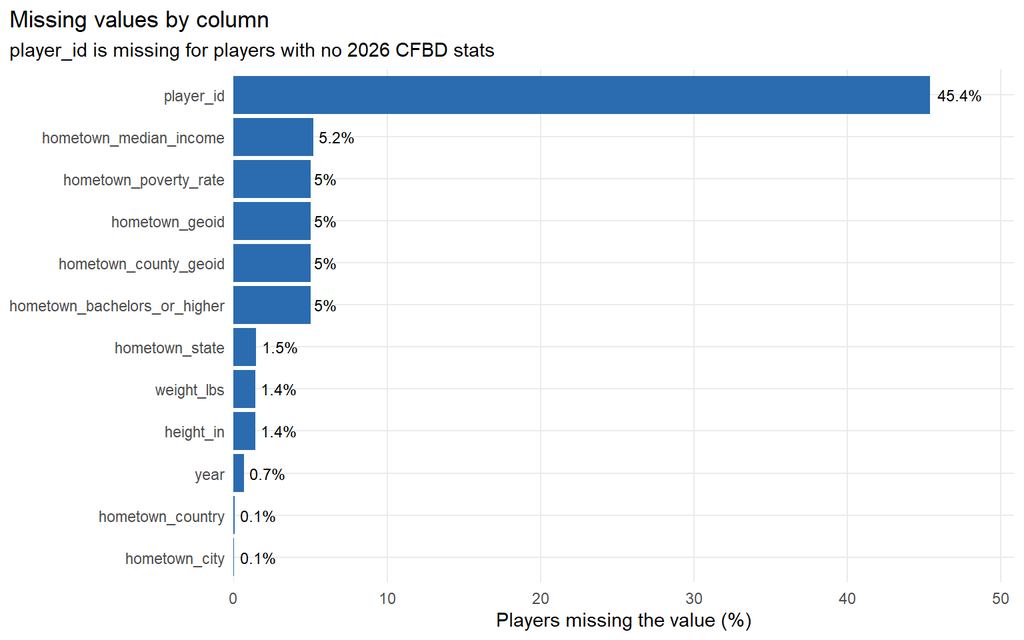

```r
quality_cols = c("year", "height_in", "weight_lbs", "hometown_city", "hometown_state", "hometown_country",
                 "player_id", "hometown_geoid", "hometown_median_income", "hometown_poverty_rate",
                 "hometown_bachelors_or_higher", "hometown_county_geoid")

tibble::tibble(column = quality_cols,
               pct_missing = purrr::map_dbl(quality_cols, ~ mean(is.na(players[[.x]])) * 100)) |>
  ggplot2::ggplot(ggplot2::aes(x = pct_missing, y = stats::reorder(column, pct_missing))) +
  ggplot2::geom_col(fill = "#2b6cb0") +
  ggplot2::geom_text(ggplot2::aes(label = paste0(round(pct_missing, 1), "%")), hjust = -0.15, size = 3.2) +
  ggplot2::scale_x_continuous(expand = ggplot2::expansion(mult = c(0, 0.12))) +
  ggplot2::labs(title = "Missing values by column",
                subtitle = "player_id is missing for players with no 2026 CFBD stats",
                x = "Players missing the value (%)", y = NULL) +
  theme_set_project
```

### Chart 2: Data quality — failed hometown joins by state

Where the remaining failed hometown joins (rule 58) are concentrated: the 15 states with the most unmatched U.S. hometowns, labelled with the share of that state’s players who are unmatched.

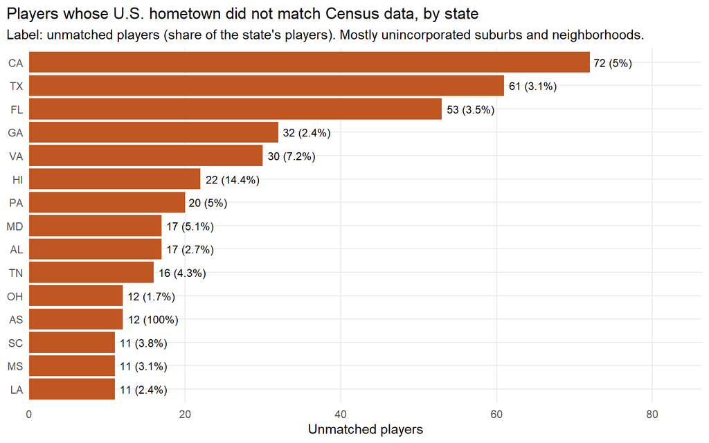

```r
players |>
  dplyr::filter(us_hometown, !is.na(hometown_state)) |>
  dplyr::group_by(hometown_state) |>
  dplyr::summarise(unmatched = sum(is.na(hometown_geoid)), pct_unmatched = mean(is.na(hometown_geoid)) * 100,
                   .groups = "drop") |>
  dplyr::slice_max(unmatched, n = 15, with_ties = FALSE) |>
  ggplot2::ggplot(ggplot2::aes(x = unmatched, y = stats::reorder(hometown_state, unmatched))) +
  ggplot2::geom_col(fill = "#c05621") +
  ggplot2::geom_text(ggplot2::aes(label = paste0(unmatched, " (", round(pct_unmatched, 1), "%)")), hjust = -0.1, size = 3.2) +
  ggplot2::scale_x_continuous(expand = ggplot2::expansion(mult = c(0, 0.2))) +
  ggplot2::labs(title = "Players whose U.S. hometown did not match Census data, by state",
                subtitle = "Label: unmatched players (share of the state's players). Mostly unincorporated suburbs and neighborhoods.",
                x = "Unmatched players", y = NULL) +
  theme_set_project
```

### Chart 3: Height and weight by position group

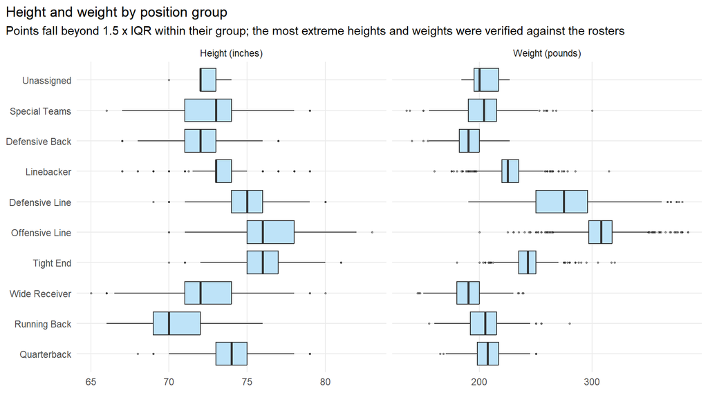

```r
players |>
  dplyr::filter(!is.na(position_group)) |>
  dplyr::select(position_group, `Height (inches)` = height_in, `Weight (pounds)` = weight_lbs) |>
  tidyr::pivot_longer(-position_group, names_to = "measure", values_to = "value") |>
  dplyr::filter(!is.na(value)) |>
  ggplot2::ggplot(ggplot2::aes(x = value, y = position_group)) +
  ggplot2::geom_boxplot(fill = "#bee3f8", outlier.size = 0.6, outlier.alpha = 0.5) +
  ggplot2::facet_wrap(~ measure, scales = "free_x") +
  ggplot2::labs(title = "Height and weight by position group",
                subtitle = "Points fall beyond 1.5 x IQR within their group; the most extreme heights and weights were verified against the rosters",
                x = NULL, y = NULL) +
  theme_set_project
```

### Chart 4: FBS players per 100,000 residents by state

Player counts come from the merged data: every U.S. player counts toward his hometown state, matched or not. State population is not in the merged data, so it is the sum of the state’s ACS county populations from the Census table.

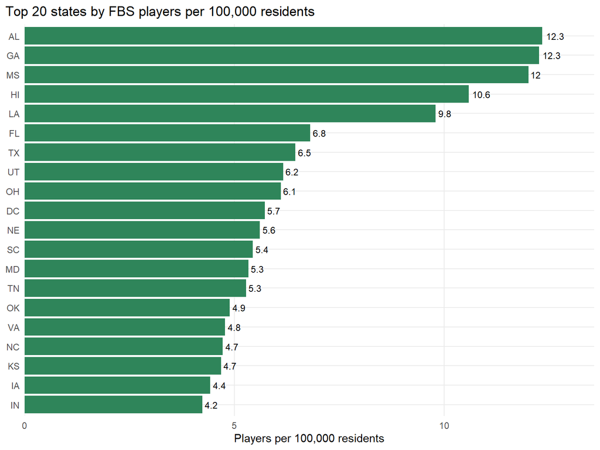

```r
state_population = census_clean |>
  dplyr::filter(geography_level == "county") |>
  dplyr::group_by(state_abbr) |>
  dplyr::summarise(population = sum(population, na.rm = TRUE), .groups = "drop")

state_rates = players |>
  dplyr::filter(us_hometown, !is.na(hometown_state)) |>
  dplyr::count(state_abbr = as.character(hometown_state), name = "players") |>
  dplyr::inner_join(state_population, by = "state_abbr") |>
  dplyr::mutate(per_100k = players / population * 1e5)

state_rates |>
  dplyr::slice_max(per_100k, n = 20) |>
  ggplot2::ggplot(ggplot2::aes(x = per_100k, y = stats::reorder(state_abbr, per_100k))) +
  ggplot2::geom_col(fill = "#2f855a") +
  ggplot2::geom_text(ggplot2::aes(label = round(per_100k, 1)), hjust = -0.2, size = 3.2) +
  ggplot2::scale_x_continuous(expand = ggplot2::expansion(mult = c(0, 0.1))) +
  ggplot2::labs(title = "Top 20 states by FBS players per 100,000 residents",
                x = "Players per 100,000 residents", y = NULL) +
  theme_set_project
```

### Table 8: Communities producing the most FBS players per capita

Matched hometown communities (places and townships) with at least 10,000 residents, ranked by players per 10,000 residents. All values come from the merged dataset. Smaller communities are left out because one or two players would give them extreme rates.

```r
communities |>
  dplyr::filter(hometown_population >= 1e4) |>
  dplyr::slice_max(players_per_10k, n = 15, with_ties = FALSE) |>
  dplyr::transmute(Community = community, Level = hometown_match_level, Players = players,
                   Population = hometown_population, `Players per 10k` = players_per_10k,
                   `Median income ($)` = hometown_median_income, `Poverty rate (%)` = hometown_poverty_rate,
                   `Bachelor's+ (%)` = hometown_bachelors_or_higher, `Density (per sq mi)` = hometown_population_density) |>
  knitr::kable(digits = 1, format.args = list(big.mark = ","))
```

| Community | Level | Players | Population | Players per 10k | Median income ($) | Poverty rate (%) | Bachelor’s+ (%) | Density (per sq mi) |
| --- | --- | --- | --- | --- | --- | --- | --- | --- |
| Buford, GA | Place | 38 | 17,997 | 21.1 | 69,471 | 12.6 | 29.3 | 946.3 |
| Katy, TX | Place | 50 | 25,184 | 19.9 | 114,912 | 8.1 | 48.8 | 1,646.7 |
| Suwanee, GA | Place | 30 | 22,349 | 13.4 | 103,260 | 10.1 | 62.5 | 2,007.8 |
| Fairburn, GA | Place | 22 | 16,831 | 13.1 | 91,897 | 17.5 | 38.5 | 998.4 |
| Humble, TX | Place | 20 | 16,521 | 12.1 | 57,011 | 18.8 | 17.4 | 1,666.7 |
| Richmond, TX | Place | 15 | 12,582 | 11.9 | 50,337 | 15.7 | 18.9 | 2,922.9 |
| Naples, FL | Place | 23 | 19,704 | 11.7 | 153,182 | 6.5 | 64.3 | 1,601.6 |
| Covington, GA | Place | 17 | 14,584 | 11.7 | 58,810 | 20.4 | 27.2 | 920.7 |
| Loganville, GA | Place | 17 | 15,527 | 10.9 | 83,605 | 8.9 | 27.0 | 2,098.1 |
| Pickerington, OH | Place | 26 | 24,477 | 10.6 | 111,833 | 3.6 | 47.2 | 2,400.8 |
| Ewa Beach, HI | Place | 15 | 14,376 | 10.4 | 124,323 | 4.9 | 21.9 | 12,068.0 |
| Irmo, SC | Place | 12 | 11,813 | 10.2 | 80,489 | 9.2 | 39.2 | 1,730.3 |
| Snellville, GA | Place | 20 | 21,620 | 9.3 | 89,896 | 8.9 | 36.2 | 2,060.4 |
| Powder Springs, GA | Place | 16 | 18,009 | 8.9 | 105,070 | 14.6 | 41.0 | 2,263.7 |
| Moody, AL | Place | 11 | 13,488 | 8.2 | 86,627 | 7.7 | 28.8 | 550.0 |

### Chart 5: Community characteristics vs. players per capita

Player counts come from the merged data. Census places with at least 10,000 residents (including places with no FBS players, which come from the Census table) are split into ten equal-sized groups (deciles) for each characteristic. Each point is the decile’s combined rate: its total players divided by its total population. Density is shown as log10 (2 = 100, 3 = 1,000, 4 = 10,000 people per square mile).

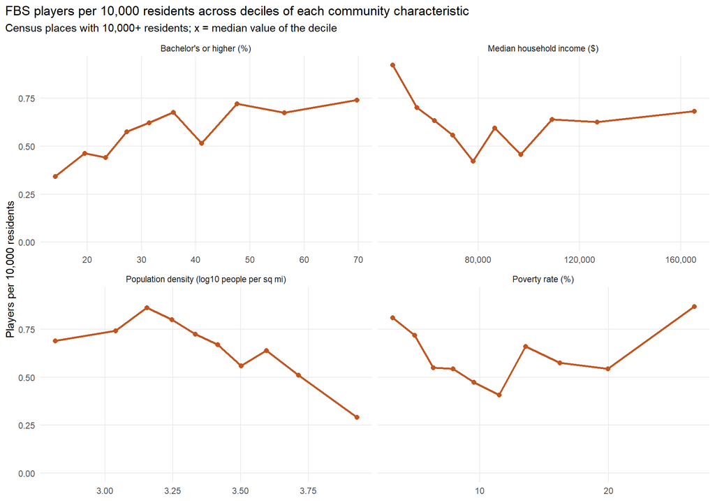

```r
characteristics = c(`Median household income ($)`       = "median_income",
                    `Population density (log10 people per sq mi)` = "population_density",
                    `Poverty rate (%)`                  = "poverty_rate",
                    `Bachelor's or higher (%)`          = "bachelors_or_higher")

purrr::imap_dfr(characteristics, function(col, label) {
  places |>
    dplyr::filter(population >= 1e4, !is.na(.data[[col]])) |>
    dplyr::mutate(decile = dplyr::ntile(.data[[col]], 10)) |>
    dplyr::group_by(decile) |>
    dplyr::summarise(value = stats::median(.data[[col]]),
                     players_per_10k = sum(players) / sum(population) * 1e4, .groups = "drop") |>
    dplyr::mutate(value = if (col == "population_density") log10(value) else value,
                  characteristic = label)
}) |>
  ggplot2::ggplot(ggplot2::aes(x = value, y = players_per_10k)) +
  ggplot2::geom_line(colour = "#c05621", linewidth = 0.9) +
  ggplot2::geom_point(colour = "#c05621", size = 2) +
  ggplot2::facet_wrap(~ characteristic, scales = "free_x") +
  ggplot2::scale_x_continuous(labels = scales::label_comma()) +
  ggplot2::expand_limits(y = 0) +
  ggplot2::labs(title = "FBS players per 10,000 residents across deciles of each community characteristic",
                subtitle = "Census places with 10,000+ residents; x = median value of the decile",
                x = NULL, y = "Players per 10,000 residents") +
  theme_set_project
```

### Table 9: Correlation of community characteristics with players per capita

Spearman rank correlations for Census places with at least 10,000 residents (including places with no players). Spearman is used because the rates are heavily skewed. University proximity is not available and thus removed from the scope of analysis.

```r
community_10k = dplyr::filter(places, population >= 1e4)

tibble::tibble(
  characteristic = c("Median household income", "Population density", "Poverty rate",
                     "Bachelor's or higher", "Population"),
  column         = c("median_income", "population_density", "poverty_rate", "bachelors_or_higher", "population")
) |>
  dplyr::mutate(
    test        = purrr::map(column, ~ suppressWarnings(stats::cor.test(community_10k$players_per_10k,
                                                                         community_10k[[.x]], method = "spearman"))),
    spearman_rho = purrr::map_dbl(test, ~ unname(.x$estimate)),
    p_value      = purrr::map_dbl(test, "p.value"),
    places       = purrr::map_int(column, ~ sum(!is.na(community_10k[[.x]])))
  ) |>
  dplyr::select(characteristic, places, spearman_rho, p_value) |>
  dplyr::arrange(dplyr::desc(abs(spearman_rho))) |>
  knitr::kable(digits = c(0, 0, 3, 4), col.names = c("Characteristic", "Places", "Spearman rho", "p-value"))
```

| Characteristic | Places | Spearman rho | p-value |
| --- | --- | --- | --- |
| Population | 4226 | 0.274 | 0.0000 |
| Population density | 4226 | -0.121 | 0.0000 |
| Bachelor’s or higher | 4226 | 0.112 | 0.0000 |
| Poverty rate | 4226 | 0.017 | 0.2772 |
| Median household income | 4226 | 0.004 | 0.8064 |